# Characterization Package Specification

Jenna Reps

2025-09-09

# 1 Time-to-event

## 1.1 Inputs

A vector of targetIds and a vector of outcomeIds

## 1.2 Output

Summary data.frame with the counts of how often an outcome occurred within a time-period relative to the first target index date for each combination of target and outcome. The counts are stratified by whether the outcome was first event or subsequent and the timing category for when the outcome occurred (before first target exposure, during first target exposure, during a subsequent target exposure, between target exposures and after last target exposure).

## 1.3 Worked Example

### 1.3.1 Example Inputs

Here we consider the inputs are:

```r
targetIds <- c(1)
outcomeIds <- c(2)
```

Consider we have five patients; the target cohort (dates each of the five patients are exposed to a drug) is in Table 1 and the outcome cohort (dates each of the five patients have the outcome) is in Table 2. This is also illustrated in Figures 1 and 2.

### 1.3.2 Example Data Image

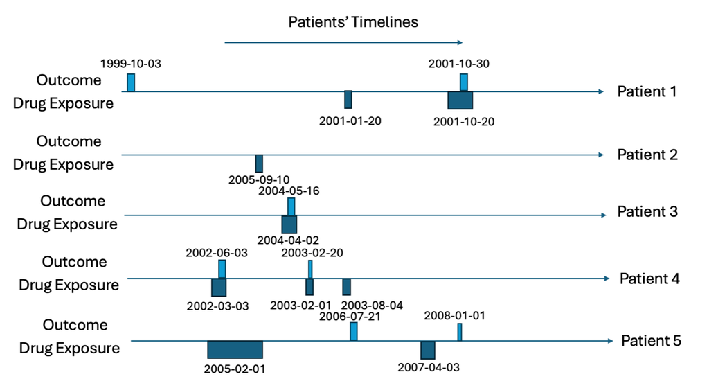

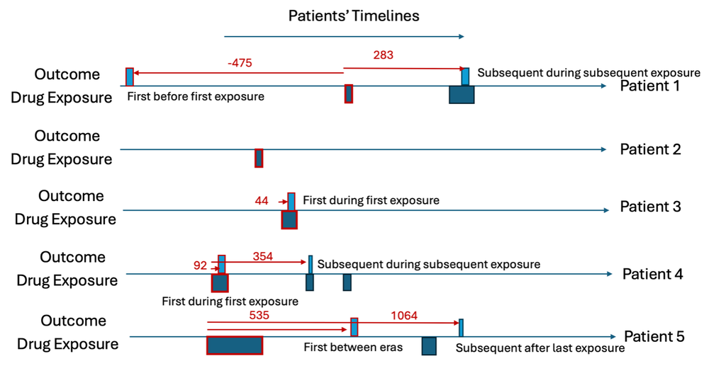

### 1.3.3 Example Data Table

Table: Example time-to-event data with dates.

Example time-to-event data with timing.

| patientId | cohortDefinitionId | cohortStartDate | cohortEndDate |
| --- | --- | --- | --- |
| 1 | 1 | 2001-01-20 | 2001-01-25 |
| 1 | 1 | 2001-10-20 | 2001-12-05 |
| 2 | 1 | 2005-09-10 | 2005-09-15 |
| 3 | 1 | 2004-04-02 | 2004-05-17 |
| 4 | 1 | 2002-03-03 | 2002-06-12 |
| 4 | 1 | 2003-02-01 | 2003-02-30 |
| 4 | 1 | 2003-08-04 | 2003-08-24 |
| 5 | 1 | 2005-02-01 | 2005-10-08 |
| 5 | 1 | 2007-04-03 | 2007-05-03 |

Example time-to-event data with timing.

| patientId | cohortDefinitionId | cohortStartDate | cohortEndDate |
| --- | --- | --- | --- |
| 1 | 2 | 1999-10-03 | 1999-10-08 |
| 1 | 2 | 2001-10-30 | 2001-11-07 |
| 3 | 2 | 2004-05-16 | 2004-05-18 |
| 4 | 2 | 2002-06-03 | 2002-06-14 |
| 4 | 2 | 2003-02-20 | 2003-03-01 |
| 5 | 2 | 2006-07-21 | 2006-08-03 |
| 5 | 2 | 2008-01-01 | 2008-01-09 |

For all rows in the outcome table, we calculate the time between the patients first exposure in the target cohort and the outcome date (time-to-event), we classify the ‘type’ as the timing of when the outcome occurs with ‘before first exposure’ meaning the outcome occurs before the patient is observed in the target cohort, ‘during first’ means the outcome occurs during the first target cohort exposure, ‘between eras’ means the outcome occurs between target exposures, ‘during subsequent’ means the outcome occurs during a non-first target exposure and ‘after last exposure’ means the outcome occurs after the last exposure in the target cohort’s end date for the patient. The outcome type is classified whether the outcome is the ‘first occurrence’ or a ‘subsequent occurrence’. Let’s consider patient 1, he has the outcome twice. The first outcome occurs 475 days before his first target exposure and his second outcome occurs 283 days after his first target exposure. The second outcome for patient 1 occurs during a subsequent target exposure era (not the first). Patient 2 does not have the outcome so does not contribute to the time-to-event. Patient 3 has her first (and only) outcome during the first exposure to the drug and 44 days after she started the drug for the first time. Patient 4 has the outcome twice, 92 days after the first exposure to the drug and 354 days after. The first time she has the outcome is during the first exposure to the drug and the subsequent time she has the outcome is during her second exposure (subsequent exposure). Patient 5 has the outcome twice, 535 days after he is first exposure to the drug and 1064 days after. The first time he has the outcome occurs between drug exposure eras and the subsequent outcome occurs after the last exposure era. This is summarized in Table 3.

Table: Table 3: Time-to-event intermediate summary.

| patientId | outcomeDate | firstExposureDate | timeToEvent | type | outcomeType |
| --- | --- | --- | --- | --- | --- |
| 1 | 1999-10-03 | 2001-01-20 | -475 | Before first exposure | First |
| 1 | 2001-10-30 | 2001-01-20 | 283 | During subsequent | Subsequent |
| 3 | 2004-05-16 | 2004-04-02 | 44 | During first | First |
| 4 | 2002-06-03 | 2002-03-03 | 92 | During first | First |
| 4 | 2003-02-20 | 2002-03-03 | 354 | During subsequent | Subsequent |
| 5 | 2006-07-21 | 2005-02-01 | 535 | Between eras | First |
| 5 | 2008-01-01 | 2005-02-01 | 1064 | After last exposure | Subsequent |

The time-to-event output aggregates the summary table into three different perspectives:

- 1-day aggregate – this calculates the total number of patients that have the outcome at each time-to-event day grouped by type and outcome type. Only looks at outcomes between -100 days and 100 days for the time-to-event.
- 30-day aggregate – this calculates the total number of patients that have the outcome at each 30-day sliding window for time-to-event (e.g., 0-29, 30-59, 60-89, etc.) grouped by type and outcome type. Only looks at outcomes between -1095 days and 1095 days for the time-to-event.
- 365-day aggregate – this calculates the total number of patients that have the outcome at each 365-day sliding window for time-to-event (e.g., 0-365, 366-730, 731-1095, etc.) grouped by type and outcome type. Only looks at outcomes between -1095 days and 1095 days for the time-to-event.

The summary results that would be output by time-to-event are displayed in Table 4.

Table: Table 4: Time-to-event output.

| timeType | Type | outcomeType | timeStart | timeEnd | count |
| --- | --- | --- | --- | --- | --- |
| 1-day | During first | First | 44 | 44 | 1 |
| 1-day | During first | First | 92 | 92 | 1 |
| 30-day | Before first exposure | First | -481 | -450 | 1 |
| 30-day | During first | First | 31 | 60 | 1 |
| 30-day | During first | First | 91 | 120 | 1 |
| 30-day | During subsequent | Subsequent | 271 | 300 | 1 |
| 30-day | During subsequent | Subsequent | 331 | 360 | 1 |
| 30-day | Between eras | First | 511 | 540 | 1 |
| 30-day | After last exposure | Subsequent | 1051 | 1080 | 1 |
| 365-day | Before first exposure | First | -731 | -365 | 1 |
| 365-day | During first | First | 1 | 365 | 2 |
| 365-day | During subsequent | Subsequent | 1 | 365 | 2 |
| 365-day | Between eras | First | 366 | 730 | 1 |
| 365-day | After last exposure | Subsequent | 731 | 1095 | 1 |